# R Notebook

EDA process of a dataset of concrete making.

# Import packages

```r
# Delete all old variables.
rm(list=ls())
# libraries needed to use
Packages <- c("dplyr", "ggplot2", "tidyverse", "corrplot", "readxl", "RColorBrewer", "psych", "mlbench", "caret", "lmtest")
lapply(Packages, library, character.only = TRUE)
```

[output not shown]

Because this notebook is so long, a lot of packages are needed to conduct this analysis experiment.

# Import data

Set the directory which has the data

```r
setwd("D:/2ndYear/2ndsemester/ThietKePhanTichThucNghiem/Do An")
```

Load data into ‘data’ variable

```r
data<- read_excel("Concrete_Data.xls")
```

Take a look at the columns’ names

```r
names(data)
```

```
[1] "Cement (component 1)(kg in a m^3 mixture)"             "Blast Furnace Slag (component 2)(kg in a m^3 mixture)"
[3] "Fly Ash (component 3)(kg in a m^3 mixture)"            "Water  (component 4)(kg in a m^3 mixture)"
[5] "Superplasticizer (component 5)(kg in a m^3 mixture)"   "Coarse Aggregate  (component 6)(kg in a m^3 mixture)"
[7] "Fine Aggregate (component 7)(kg in a m^3 mixture)"     "Age (day)"
[9] "Concrete compressive strength(MPa, megapascals)"
```

Because their names are too long, they make reading and using data more complicated. We should rename them shorter.

```r
names(data)<- c("Cement", "Blast", "FlyAsh", "Water", "SupPlas", "CoarseAgg","FineAgg","age", 'strength')
names(data)
```

```
[1] "Cement"    "Blast"     "FlyAsh"    "Water"     "SupPlas"   "CoarseAgg" "FineAgg"   "age"       "strength"
```

Now their names are short, so we will find it easy to view and use to apply in the code.

# Descriptive Statistics

```r
# psych library for using 'describe' function
library(psych)
describe(data)
```

|  | vars | n | mean | sd | median | trimmed | mad | min | max | range | skew | kurtosis | se |
| --- | --- | --- | --- | --- | --- | --- | --- | --- | --- | --- | --- | --- | --- |
| Cement | 1 | 1030 | 281.17 | 104.51 | 272.90 | 273.47 | 117.72 | 102.00 | 540.0 | 438.00 | 0.51 | -0.53 | 3.26 |
| Blast | 2 | 1030 | 73.90 | 86.28 | 22.00 | 62.43 | 32.62 | 0.00 | 359.4 | 359.40 | 0.80 | -0.52 | 2.69 |
| FlyAsh | 3 | 1030 | 54.19 | 64.00 | 0.00 | 46.85 | 0.00 | 0.00 | 200.1 | 200.10 | 0.54 | -1.33 | 1.99 |
| Water | 4 | 1030 | 181.57 | 21.36 | 185.00 | 181.19 | 19.27 | 121.75 | 247.0 | 125.25 | 0.07 | 0.11 | 0.67 |
| SupPlas | 5 | 1030 | 6.20 | 5.97 | 6.35 | 5.56 | 7.87 | 0.00 | 32.2 | 32.20 | 0.91 | 1.39 | 0.19 |
| CoarseAgg | 6 | 1030 | 972.92 | 77.75 | 968.00 | 973.49 | 68.64 | 801.00 | 1145.0 | 344.00 | -0.04 | -0.61 | 2.42 |
| FineAgg | 7 | 1030 | 773.58 | 80.18 | 779.51 | 776.41 | 67.44 | 594.00 | 992.6 | 398.60 | -0.25 | -0.11 | 2.50 |
| age | 8 | 1030 | 45.66 | 63.17 | 28.00 | 32.53 | 31.13 | 1.00 | 365.0 | 364.00 | 3.26 | 12.07 | 1.97 |
| strength | 9 | 1030 | 35.82 | 16.71 | 34.44 | 34.96 | 16.20 | 2.33 | 82.6 | 80.27 | 0.42 | -0.32 | 0.52 |

```r
# no longer need this library, so we will remove/detach it
detach(package:psych)
```

The dataset **Concrete Compressive Strength** was collected by professor I-Cheng Yeh from Chung-Hua University. It can be downloaded from [this site](https://archive.ics.uci.edu/ml/datasets/concrete+compressive+strength).

*Number of Instances*: 1030

*Number of Attributes:* 9

*Date Donated* 2007 August 3rd

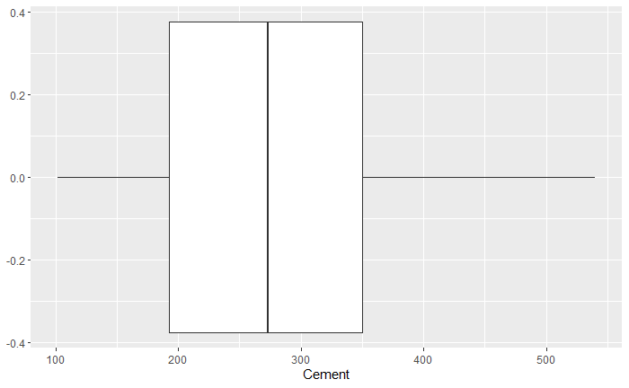

```r
#Box plot of Cement
ggplot(data,aes(x=Cement))+geom_boxplot()
```

Cement elements have a data distribution towards the middle.

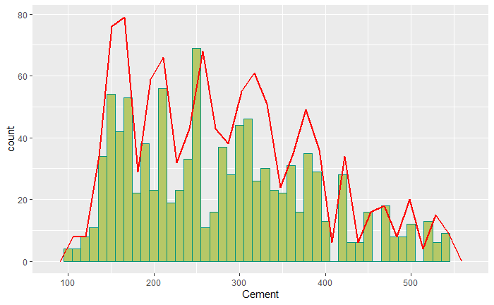

```r
# Histogram of cement
ggplot(data, aes(x=Cement)) +
  geom_histogram(position = "identity", binwidth = 10, color="#01937C", fill="#B6C867") +
  geom_freqpoly(color='red', size = 1)
```

The spread and distribution of the factor Cement are not skewed to one side, so there is few outliers.

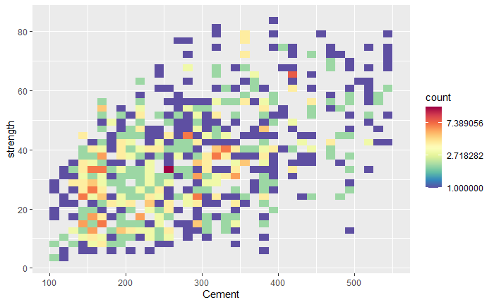

```r
my_colors=colorRampPalette(rev(brewer.pal(11,'Spectral')))
ggplot(data = data,aes(x=Cement, y=strength))+
  stat_bin2d(bins=35)+
  scale_fill_gradientn(colours=my_colors(32), trans="log")
```

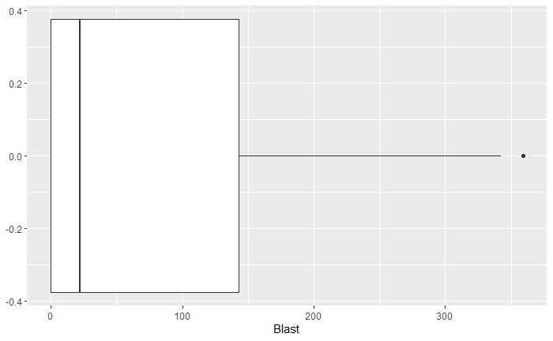

```r
ggplot(data,aes(x=Blast))+geom_boxplot()
```

[figure not shown]

# Caret - Feature selection

```r
set.seed(7)
```

RFE is wrapper-style, because it uses the Random Forest algorithm in its core to help evaluate the effectiveness of attribute selection. It starts with using the entire attribute, then effectively removes it gradually to achieve the desired number of important attributes. This efficient computational process has made it popular among attribute selection methods.

```r
control <- rfeControl(functions=rfFuncs, method="cv", number=10)
# run the RFE algorithm
results <- rfe(data[,1:8],
               as.matrix(data[,9]),
               sizes=c(1:8),
               rfeControl=control)
```

```r
# summarize the results
print(results)
```

```
Recursive feature selection

Outer resampling method: Cross-Validated (10 fold)

Resampling performance over subset size:
```

|  | Variables | RMSE | Rsquared | MAE | RMSESD | RsquaredSD | MAESD | Selected |
| --- | --- | --- | --- | --- | --- | --- | --- | --- |
| 1 | 1 | 12.927 | 0.4015 | 10.256 | 0.7136 | 0.09824 | 0.6897 |  |
| 2 | 2 | 8.976 | 0.7152 | 7.088 | 0.5533 | 0.05000 | 0.5001 |  |
| 3 | 3 | 7.419 | 0.8190 | 5.643 | 0.4525 | 0.02835 | 0.4007 |  |
| 4 | 4 | 6.577 | 0.8700 | 4.979 | 0.5780 | 0.03046 | 0.3764 |  |
| 5 | 5 | 6.199 | 0.8978 | 4.871 | 0.4091 | 0.02151 | 0.2519 |  |
| 6 | 6 | 4.889 | 0.9237 | 3.566 | 0.4643 | 0.02006 | 0.2613 | * |
| 7 | 7 | 5.028 | 0.9231 | 3.668 | 0.4888 | 0.02151 | 0.2353 |  |
| 8 | 8 | 5.176 | 0.9204 | 3.809 | 0.5070 | 0.02412 | 0.2385 |  |

```
The top 5 variables (out of 6):
   age, Cement, FineAgg, Water, Blast
```

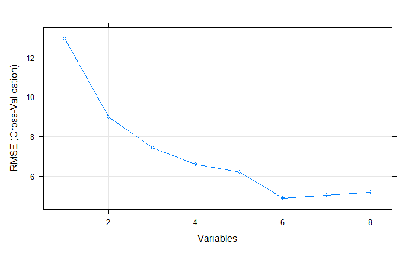

```r
# plot the results
plot(results, type=c("g", "o"))
```

```r
detach(package:mlbench)
detach(package:caret)
```

# ANOVA Analysis

## First ANOVA

We can make two hypotheses as follows:

- *Null hypotheses 1*: Means of individual attributes are not statistically significant.
- *Alternative hypotheses 1*: Means of individual attributes are statistically significant.
- *Null hypotheses 2*: There is no interaction between attributes.
- *Alternative hypotheses 2*: There is interaction between attributes.

```r
av1<-aov(strength~age* Cement* Water* FineAgg* Blast, data=data)
summary(av1)
```

```
                                Df Sum Sq Mean Sq F value   Pr(>F)
age                              1  31061   31061 366.004  < 2e-16 ***
Cement                           1  64105   64105 755.387  < 2e-16 ***
Water                            1  34597   34597 407.679  < 2e-16 ***
FineAgg                          1  11712   11712 138.006  < 2e-16 ***
Blast                            1  20891   20891 246.175  < 2e-16 ***
age:Cement                       1   1966    1966  23.166 1.72e-06 ***
age:Water                        1  10706   10706 126.151  < 2e-16 ***
Cement:Water                     1     19      19   0.219 0.639655
age:FineAgg                      1   5532    5532  65.187 1.95e-15 ***
Cement:FineAgg                   1    255     255   2.999 0.083621 .
Water:FineAgg                    1    529     529   6.232 0.012707 *
age:Blast                        1      9       9   0.101 0.751053
Cement:Blast                     1   2150    2150  25.338 5.71e-07 ***
Water:Blast                      1    149     149   1.753 0.185842
FineAgg:Blast                    1   2017    2017  23.773 1.26e-06 ***
age:Cement:Water                 1    161     161   1.902 0.168202
age:Cement:FineAgg               1   2186    2186  25.756 4.62e-07 ***
age:Water:FineAgg                1    182     182   2.149 0.142971
Cement:Water:FineAgg             1   1458    1458  17.175 3.70e-05 ***
age:Cement:Blast                 1    134     134   1.584 0.208537
age:Water:Blast                  1   5653    5653  66.614 9.89e-16 ***
Cement:Water:Blast               1   1079    1079  12.710 0.000381 ***
age:FineAgg:Blast                1    120     120   1.418 0.234045
Cement:FineAgg:Blast             1     18      18   0.210 0.647162
Water:FineAgg:Blast              1   2818    2818  33.205 1.10e-08 ***
age:Cement:Water:FineAgg         1      7       7   0.081 0.776380
age:Cement:Water:Blast           1    569     569   6.708 0.009737 **
age:Cement:FineAgg:Blast         1    267     267   3.150 0.076222 .
age:Water:FineAgg:Blast          1   1686    1686  19.864 9.26e-06 ***
Cement:Water:FineAgg:Blast       1    421     421   4.959 0.026174 *
age:Cement:Water:FineAgg:Blast   1     22      22   0.257 0.612328
Residuals                      998  84695      85
---
Signif. codes:  0 ‘***’ 0.001 ‘**’ 0.01 ‘*’ 0.05 ‘.’ 0.1 ‘ ’ 1
```

## Second ANOVA

In this 2nd ANOVA test, we only choose individual attributes and their interactions that are statistically significant at the 1st ANOVA test to conduct the test.

```r
# Second ANOVA
av2<-aov(strength~age+ Cement+ Water+ FineAgg+ Blast
         +age:Cement+ age:Water+ age:FineAgg+ Water:FineAgg+
           Cement:Blast+ FineAgg:Blast+age:Cement:FineAgg+
           Cement:Water:FineAgg+ age:Water:Blast+
           Cement:Water:Blast+ Water:FineAgg:Blast+
           age:Cement:Water:Blast+
           Cement:Water:FineAgg:Blast+ age:Water:FineAgg:Blast
         ,data=data)
summary(av2)
```

```
                             Df Sum Sq Mean Sq F value   Pr(>F)
age                           1  31061   31061 335.565  < 2e-16 ***
Cement                        1  64105   64105 692.564  < 2e-16 ***
Water                         1  34597   34597 373.774  < 2e-16 ***
FineAgg                       1  11712   11712 126.528  < 2e-16 ***
Blast                         1  20891   20891 225.702  < 2e-16 ***
age:Cement                    1   1966    1966  21.240 4.57e-06 ***
age:Water                     1  10706   10706 115.659  < 2e-16 ***
age:FineAgg                   1   5543    5543  59.887 2.43e-14 ***
Water:FineAgg                 1    696     696   7.516  0.00622 **
Cement:Blast                  1   2109    2109  22.786 2.08e-06 ***
FineAgg:Blast                 1   1655    1655  17.884 2.56e-05 ***
age:Cement:FineAgg            1   1821    1821  19.672 1.02e-05 ***
Cement:Water:FineAgg          1      7       7   0.079  0.77930
age:Water:Blast               1    379     379   4.091  0.04338 *
Cement:Water:Blast            1    266     266   2.874  0.09032 .
Water:FineAgg:Blast           1     48      48   0.513  0.47388
age:Cement:Water:Blast        1    125     125   1.352  0.24519
Cement:Water:FineAgg:Blast    1    812     812   8.778  0.00312 **
age:Water:FineAgg:Blast       1   5185    5185  56.019 1.56e-13 ***
Residuals                  1010  93488      93
---
Signif. codes:  0 ‘***’ 0.001 ‘**’ 0.01 ‘*’ 0.05 ‘.’ 0.1 ‘ ’ 1
```

- Four interactions were not statistically significant, including *Cement:Water:FineAgg, Cement:Water:Blast, Water:FineAgg:Blast, age:Cement:Water:Blast* with P values of 0.77930, 0.09032, 0.47388, 0.24519, respectively. (both greater than 0.05)
- The remaining individual attributes and interactions are all statistically significant.

## Third ANOVA

In this 3rd ANOVA test, we remove the interactions between attributes that are not statistically significant in the 2nd ANOVA test and take the rest to conduct the test.

```r
av3<-aov(strength~age+ Cement+ Water+ FineAgg+ Blast
         +age:Cement+ age:Water+ age:FineAgg+Water:FineAgg+
           Cement:Blast+ FineAgg:Blast+
           age:Cement:FineAgg+ age:Water:Blast
         +Cement:Water:FineAgg:Blast+ age:Water:FineAgg:Blast
         ,data=data)
summary(av3)
```

```
                             Df Sum Sq Mean Sq F value   Pr(>F)
age                           1  31061   31061 330.053  < 2e-16 ***
Cement                        1  64105   64105 681.190  < 2e-16 ***
Water                         1  34597   34597 367.635  < 2e-16 ***
FineAgg                       1  11712   11712 124.450  < 2e-16 ***
Blast                         1  20891   20891 221.995  < 2e-16 ***
age:Cement                    1   1966    1966  20.891 5.46e-06 ***
age:Water                     1  10706   10706 113.760  < 2e-16 ***
age:FineAgg                   1   5543    5543  58.903 3.88e-14 ***
Water:FineAgg                 1    696     696   7.393  0.00666 **
Cement:Blast                  1   2109    2109  22.411 2.51e-06 ***
FineAgg:Blast                 1   1655    1655  17.590 2.98e-05 ***
age:Cement:FineAgg            1   1821    1821  19.349 1.20e-05 ***
age:Water:Blast               1    348     348   3.697  0.05479 .
Cement:Water:FineAgg:Blast    1    704     704   7.483  0.00634 **
age:Water:FineAgg:Blast       1   3833    3833  40.727 2.66e-10 ***
Residuals                  1014  95425      94
---
Signif. codes:  0 ‘***’ 0.001 ‘**’ 0.01 ‘*’ 0.05 ‘.’ 0.1 ‘ ’ 1
```

- A non-statistically significant interaction included *age:Water:Blast* with a P-value = 0.05479 (greater than 0.05).
- The remaining individual attributes and interactions are all statistically significant.

## Fourth ANOVA

Similar to the 2nd and 3rd ANOVA tests, we exclude the interactions between the attributes that are not statistically significant and take the remainder for testing.

```r
# Fourth ANOVA
av4<-aov(strength~age+ Cement+ Water+ FineAgg+ Blast
         + age:Cement+ age:Water+ age:FineAgg+ Water:FineAgg+ Cement:Blast+ FineAgg:Blast
         +age:Cement:FineAgg
         + Cement:Water:FineAgg:Blast+ age:Water:FineAgg:Blast
         ,data=data)
summary(av4)
```

```
                             Df Sum Sq Mean Sq F value   Pr(>F)
age                           1  31061   31061 316.405  < 2e-16 ***
Cement                        1  64105   64105 653.022  < 2e-16 ***
Water                         1  34597   34597 352.433  < 2e-16 ***
FineAgg                       1  11712   11712 119.304  < 2e-16 ***
Blast                         1  20891   20891 212.815  < 2e-16 ***
age:Cement                    1   1966    1966  20.027 8.50e-06 ***
age:Water                     1  10706   10706 109.056  < 2e-16 ***
age:FineAgg                   1   5543    5543  56.468 1.25e-13 ***
Water:FineAgg                 1    696     696   7.087  0.00789 **
Cement:Blast                  1   2109    2109  21.485 4.03e-06 ***
FineAgg:Blast                 1   1655    1655  16.863 4.34e-05 ***
age:Cement:FineAgg            1   1821    1821  18.549 1.82e-05 ***
Cement:Water:FineAgg:Blast    1    616     616   6.273  0.01242 *
age:Water:FineAgg:Blast       1     55      55   0.558  0.45510
Residuals                  1015  99640      98
---
Signif. codes:  0 ‘***’ 0.001 ‘**’ 0.01 ‘*’ 0.05 ‘.’ 0.1 ‘ ’ 1
```

- An interaction that is not statistically significant includes *age:Water:FineAgg:Blast* with P-value = 0.45510 (greater than 0.05).
- The remaining individual attributes and interactions are all statistically significant.

## Fifth ANOVA

```r
# Fifth ANOVA
av5<-aov(strength~age+ Cement+ Water+ FineAgg+ Blast
         + age:Cement+ age:Water+ age:FineAgg+ Water:FineAgg+
           Cement:Blast+ FineAgg:Blast+age:Cement:FineAgg
         + Cement:Water:FineAgg:Blast
         ,data=data)
summary(av5)
```

```
                             Df Sum Sq Mean Sq F value   Pr(>F)
age                           1  31061   31061 316.543  < 2e-16 ***
Cement                        1  64105   64105 653.306  < 2e-16 ***
Water                         1  34597   34597 352.586  < 2e-16 ***
FineAgg                       1  11712   11712 119.356  < 2e-16 ***
Blast                         1  20891   20891 212.908  < 2e-16 ***
age:Cement                    1   1966    1966  20.036 8.46e-06 ***
age:Water                     1  10706   10706 109.103  < 2e-16 ***
age:FineAgg                   1   5543    5543  56.492 1.24e-13 ***
Water:FineAgg                 1    696     696   7.090  0.00787 **
Cement:Blast                  1   2109    2109  21.494 4.01e-06 ***
FineAgg:Blast                 1   1655    1655  16.870 4.32e-05 ***
age:Cement:FineAgg            1   1821    1821  18.557 1.81e-05 ***
Cement:Water:FineAgg:Blast    1    616     616   6.275  0.01240 *
Residuals                  1016  99695      98
---
Signif. codes:  0 ‘***’ 0.001 ‘**’ 0.01 ‘*’ 0.05 ‘.’ 0.1 ‘ ’ 1
```

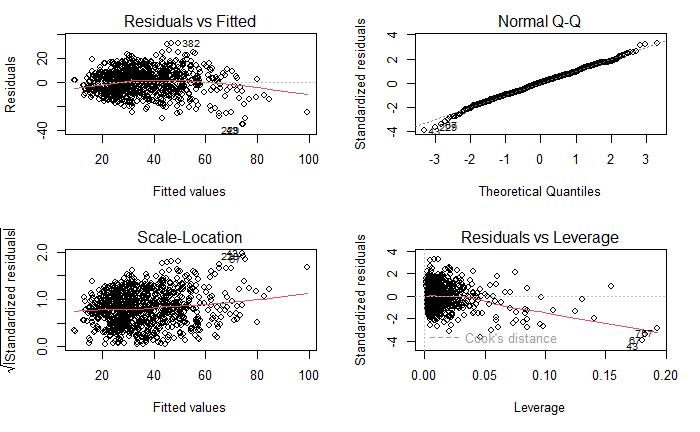

```r
par(mfrow=c(2,2))
plot(av5)
```

Check heteroscedasticity

```r
lmtest::bptest(av5,
               ~ age*Cement + age*Water + age*FineAgg + Water*FineAgg + Cement*Blast + FineAgg*Blast +
                 age*Cement*FineAgg + Cement*Water*FineAgg + age*Water*Blast + Cement*Water*Blast + Water*FineAgg*Blast +
                 age*Cement*Water*Blast + age*Water*FineAgg*Blast + Cement*Water*FineAgg*Blast +
                 I(age^2) + I(Cement^2) + I(Water^2)+ I(FineAgg^2)+ I(Blast^2),
               data = data)
```

```
    studentized Breusch-Pagan test

data:  av5
BP = 271.49, df = 33, p-value < 2.2e-16
```

Box-Cox transformation

```r
data_new <- subset(data, select = c(age, Cement, Water, FineAgg, Blast, strength) )
distBCMod <- caret::BoxCoxTrans(data_new$strength)
print(distBCMod)
```

```
Box-Cox Transformation

1030 data points used to estimate Lambda

Input data summary:
   Min. 1st Qu.  Median    Mean 3rd Qu.    Max.
  2.332  23.707  34.443  35.818  46.136  82.599

Largest/Smallest: 35.4
Sample Skewness: 0.416

Estimated Lambda: 0.6
```

```r
data_new <- cbind(data_new, strength_new=predict(distBCMod, data_new$strength)) # append the transformed variable to cars
av_new<-aov(strength~age*Cement + age*Water + age*FineAgg + Water*FineAgg + Cement*Blast + FineAgg*Blast +
              age*Cement*FineAgg + Cement*Water*FineAgg + age*Water*Blast + Cement*Water*Blast + Water*FineAgg*Blast +
              age*Cement*Water*Blast + age*Water*FineAgg*Blast + Cement*Water*FineAgg*Blast +age+ Cement+ Water+ FineAgg+ Blast, data=data)
bptest(av_new)
```

```
    studentized Breusch-Pagan test

data:  av_new
BP = 122.36, df = 28, p-value = 9.168e-14
```

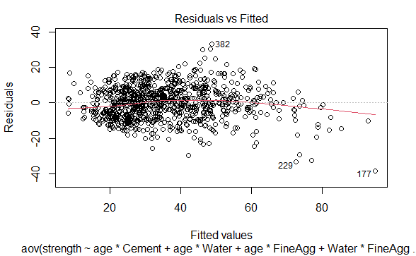

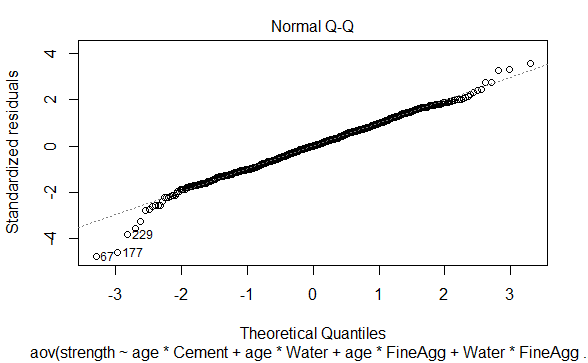

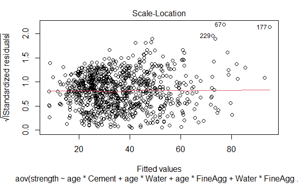

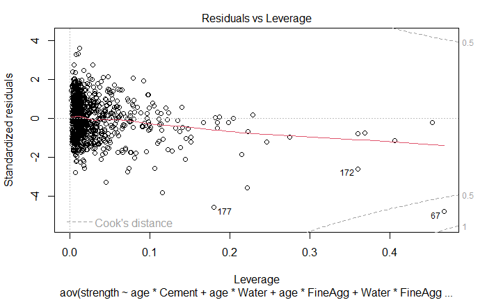

```r
plot(av_new)
```

```r
lmtest::bptest(av_new,
               ~ age*Cement + age*Water + age*FineAgg + Water*FineAgg + Cement*Blast + FineAgg*Blast +
                 age*Cement*FineAgg + Cement*Water*FineAgg + age*Water*Blast + Cement*Water*Blast + Water*FineAgg*Blast +
                 age*Cement*Water*Blast + age*Water*FineAgg*Blast + Cement*Water*FineAgg*Blast +
                 I(age^2) + I(Cement^2) + I(Water^2)+ I(FineAgg^2)+ I(Blast^2),
               data = data_new)
```

```
    studentized Breusch-Pagan test

data:  av_new
BP = 187.52, df = 33, p-value < 2.2e-16
```

# Basic regression

I will build a Linear Regression model using a basic set of parameters.

The general regression equation of the model:
$$\begin{equation}
\begin{aligned}
strength = & \beta_0 + \beta_1\times \mathrm{age} +
\beta_2\times \mathrm{Cement} + \\
& \beta_3\times Water + \beta_4\times FineAgg + \beta_5\times
Blast
\end{aligned}
\end{equation}$$
Next, we hypothesize the following:

- **Null hypothesis:** Each attribute has no effect on the output.
- **Altenative hypothesis:** Each attribute affects the output.

```r
Train <- read.csv("Train.csv")
relation_basic <- lm(formula = strength ~ age + Cement + Water + FineAgg + Blast, data=Train)
summary(relation_basic)
```

```
Call:
lm(formula = strength ~ age + Cement + Water + FineAgg + Blast,
    data = Train)

Residuals:
    Min      1Q  Median      3Q     Max
-33.624  -7.747   0.720   6.958  29.671

Coefficients:
             Estimate Std. Error t value Pr(>|t|)
(Intercept) 86.716211   7.877030  11.009  < 2e-16 ***
age          0.112919   0.006513  17.337  < 2e-16 ***
Cement       0.077919   0.004147  18.788  < 2e-16 ***
Water       -0.348970   0.021253 -16.420  < 2e-16 ***
FineAgg     -0.023886   0.006015  -3.971 7.79e-05 ***
Blast        0.055913   0.004985  11.216  < 2e-16 ***
---
Signif. codes:  0 ‘***’ 0.001 ‘**’ 0.01 ‘*’ 0.05 ‘.’ 0.1 ‘ ’ 1

Residual standard error: 10.98 on 820 degrees of freedom
Multiple R-squared:  0.5609,    Adjusted R-squared:  0.5582
F-statistic: 209.5 on 5 and 820 DF,  p-value: < 2.2e-16
```

- The results show that all five attributes have $P < 0.05$ => Altenative hypothesis is true for all attributes. The obtained regression equation is:
  $$\begin{equation}
  \begin{aligned}
  strength = & 86.716211 + 0.112919\times \mathrm{age} +
  0.077919\times \mathrm{Cement} \\
  &- 0.34897\times Water -0.023886\times FineAgg + 0.055913\times
  Blast
  \end{aligned}
  \end{equation}$$
- *R-Squared Adjusted* of basic parameter model: 0.5582.

```r
bptest(relation_basic,  ~ age + Cement + Water + FineAgg + Blast,
       data=Train)
```

```
    studentized Breusch-Pagan test

data:  relation_basic
BP = 76.448, df = 5, p-value = 4.638e-15
```

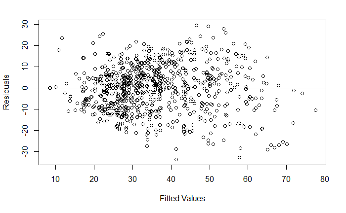

```r
plot(fitted(relation_basic), resid(relation_basic), xlab='Fitted Values', ylab='Residuals')
abline(0,0)
```

# Linear Regression

Through ANOVA testing, we have filtered out statistically significant attributes and relationships. Based on that, we get the following general regression model:
$$\begin{equation}
\begin{aligned}
strength = & \beta_0 + \beta_1\times age + \beta_2\times
Cement + \beta_3\times Water + \beta_4\times FineAgg + \beta_5\times
Blast \\
& + \beta_6\times age\times Cement + \beta_7\times age\times
Water + \beta_8\times age\times FineAgg \\
& + \beta_9\times Water\times FineAgg + \beta_{10}\times
Cement\times Blast + \beta_{11}\times FineAgg\times Blast \\
& + \beta_{12}\times age\times Cement\times FineAgg \\
& + \beta_{13}\times Cement\times Water\times FineAgg\times
Blast
\end{aligned}
\end{equation}$$

```r
relation <- lm(formula = strength~age + Cement + Water + FineAgg + Blast + age:Cement + age:Water + age:FineAgg + Water:FineAgg + Cement:Blast + FineAgg:Blast + age:Cement:FineAgg + Cement:Water:FineAgg:Blast, data=Train)
summary(relation)
```

```
Call:
lm(formula = strength ~ age + Cement + Water + FineAgg + Blast +
    age:Cement + age:Water + age:FineAgg + Water:FineAgg + Cement:Blast +
    FineAgg:Blast + age:Cement:FineAgg + Cement:Water:FineAgg:Blast,
    data = Train)

Residuals:
    Min      1Q  Median      3Q     Max
-36.051  -7.115   0.438   6.344  31.804

Coefficients:
                             Estimate Std. Error t value Pr(>|t|)
(Intercept)                 3.004e+01  2.800e+01   1.073  0.28367
age                         1.912e+00  2.039e-01   9.377  < 2e-16 ***
Cement                      6.601e-02  5.879e-03  11.227  < 2e-16 ***
Water                       3.694e-02  1.506e-01   0.245  0.80632
FineAgg                     9.009e-03  3.402e-02   0.265  0.79121
Blast                      -1.459e-01  5.123e-02  -2.848  0.00450 **
age:Cement                 -1.964e-03  3.847e-04  -5.106 4.11e-07 ***
age:Water                  -4.274e-03  3.884e-04 -11.005  < 2e-16 ***
age:FineAgg                -1.166e-03  1.995e-04  -5.845 7.35e-09 ***
Water:FineAgg              -2.672e-04  1.875e-04  -1.425  0.15443
Cement:Blast               -1.321e-04  1.809e-04  -0.731  0.46524
FineAgg:Blast               1.722e-04  6.525e-05   2.638  0.00849 **
age:Cement:FineAgg          2.398e-06  5.447e-07   4.403 1.21e-05 ***
Cement:Water:FineAgg:Blast  2.982e-09  1.426e-09   2.092  0.03679 *
---
Signif. codes:  0 ‘***’ 0.001 ‘**’ 0.01 ‘*’ 0.05 ‘.’ 0.1 ‘ ’ 1

Residual standard error: 9.899 on 812 degrees of freedom
Multiple R-squared:  0.6467,    Adjusted R-squared:  0.6411
F-statistic: 114.3 on 13 and 812 DF,  p-value: < 2.2e-16
```

- Based on the result of linear regression model, we pick out the attributes and relationships which are statistically significant and we have obtained the regression equation as follows:
  $$\begin{equation}
  \begin{aligned}
  strength = & 1.912\times age + 0.06601\times Cement -
  0.1459\times Blast - 0.001964\times age\times Cement \\
  & - 0.004274\times age\times Water - 0.001166\times age\times
  FineAgg \\
  & + 0.0001722\times FineAgg\times Blast \\
  & + 2.982\times 10^{-9} \times Cement\times Water\times
  FineAgg\times Blast
  \end{aligned}
  \end{equation}$$

A model that suffers from **heterogeneity** of covariance will render the regression results unreliable and cannot be considered an accurate model.

More specifically in regression analysis, Heteroscedasticity is the concept of residuals or errors. Then, the variance of the errors in a regression model is not stable for all predicted points. In order for the model results to be highly reliable, the variance of the residuals in all the prediction points needs to be stable.

To test the Heteroscedasticity, we address 2 hypothesis: * *Null hypothesis*: Homoscedasticity. (The model residuals are distributed with stable variance.) * *Alternative hypothesis:* heteroscedasticity (The model residuals are distributed with the scattering variance.)

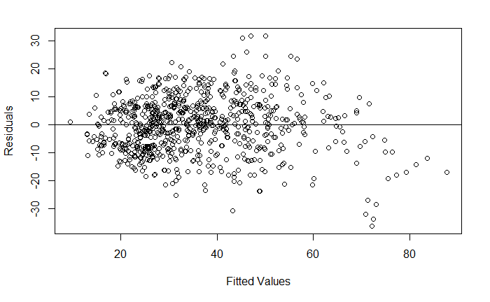

```r
plot(fitted(relation), resid(relation), xlab='Fitted Values', ylab='Residuals')
abline(0,0)
```

First, visually, we perform a graph of the correlation between the residuals and the fitted values. We see that the residuals are scattered with an increasingly random and irregular dispersion for large values. Therefore, it can be assumed that the model has encountered heteroscedasticity.

In addition, statistically, in order to achieve a more accurate test, we use the **Breusch-Pagan test** to test the two hypotheses above.

```r
anova(relation)
```

```
Analysis of Variance Table

Response: strength
                            Df Sum Sq Mean Sq  F value    Pr(>F)
age                          1  25762   25762 262.9093 < 2.2e-16 ***
Cement                       1  48810   48810 498.1230 < 2.2e-16 ***
Water                        1  27233   27233 277.9245 < 2.2e-16 ***
FineAgg                      1   9344    9344  95.3604 < 2.2e-16 ***
Blast                        1  15172   15172 154.8409 < 2.2e-16 ***
age:Cement                   1   1157    1157  11.8064 0.0006203 ***
age:Water                    1   9703    9703  99.0206 < 2.2e-16 ***
age:FineAgg                  1   2371    2371  24.1994 1.052e-06 ***
Water:FineAgg                1    487     487   4.9702 0.0260608 *
Cement:Blast                 1   2007    2007  20.4801 6.926e-06 ***
FineAgg:Blast                1   1101    1101  11.2318 0.0008412 ***
age:Cement:FineAgg           1   2082    2082  21.2481 4.685e-06 ***
Cement:Water:FineAgg:Blast   1    429     429   4.3747 0.0367865 *
Residuals                  812  79566      98
---
Signif. codes:  0 ‘***’ 0.001 ‘**’ 0.01 ‘*’ 0.05 ‘.’ 0.1 ‘ ’ 1
```

```r
bptest(relation, data=Train) # the result shows Heteroscedasticity of the dataset
```

```
    studentized Breusch-Pagan test

data:  relation
BP = 98.371, df = 13, p-value = 3.429e-15
```

From the observed results from *Breusch-Pagan test*, we see that p-value < 0.05. Therefore, rejecting the null hypothesis, the built model exists heteroscedasticity.